# Example WIC analysis using R Markdown

by Martin Brown, Martin.Brown@state.or.us

### Introduction

This RMarkdown document provides an example application of the Waste Impact Calculator (WIC) framework.

You, the reader of this document, play the part of a waste manager or sustainability analyst from Anytown, Oregon. This document shows how you use WIC to deal with a realistic waste management question. In particular, you will learn to:

- convert the waste management question into waste streams linked to scenario labels in a *massProfiles* table;
- combine your *massProfiles* with *impactFactors* and filter and summarize the results for each of those scenarios, in multiple impact categories;
- delve into the reasons the scenarios differ – and often, fail to differ; and finally,
- reflect on what WIC has and hasn’t told you.

Along the way, you’ll find pointers on how to properly combine, filter, and summarize WIC’s data tables, so that the final results actually represent the scenarios you are interested in evaluating.

### Intended audience

This document is oriented towards more technical users – those familiar with statistical or database operations. This document assumes an intermediate familiarity with the R language, especially the packages “base,” “dplyr”, and “ggplot2”.

Before using this document as the basis for new analyses, you should have a clear understanding of:

- how WIC calculates impacts for individual life cycle stages (see “Prerequisites”, below); and
- how file structures and joining commands (for example *left_join* and *full_join* in R’s dplyr package) can create sets of impacts that represent the materials life cycle.

Though R is used by the authors of this document, the WIC framework is not specifically required. You are responsible for your own work no matter what computer system you use. :)

### Prerequisites

- Read “Technical overview of the Waste Impact Calculator”. This describes the the purpose, limitations, and basic operation of WIC. It also documents the meaning of all the fields in each of WIC’s data tables – information that will, for the most part, not be repeated here.
- Experience with R as described above.

### Conventions

- the words *mass* and *weight* are used interchangeably. The distinction between these terms is important in other fields, but not in Earthbound waste management.
- weights are in short tons

### Anytown’s question and your expectations of WIC

You work for Anytown’s sustainability department and are concerned about the environmental impacts of Anytown’s municipal food waste.

In particular you are considering implementing a food waste composting scheme, but don’t know if it is worth the effort it would require. You know that composting food waste is likely to be better on an environmental impact basis than simply landfilling it, but it is unclear how big the improvement would be. Another option is the idea of trying to reduce the sheer generation of food waste through a public education campaign – which would have its own difficulties, but, as an “upstream” strategy, might be more powerful than the “downstream” one of composting.

You will use WIC to compare Anytown’s current treatment of food waste (the “baseline” scenario) with two scenarios for increasing composting of food waste, and two scenarios for reducing food waste generation.

You expect that WIC will estimate life cycle impacts for each scenario, in enough detail that the reasons for differences between scenarios can be understood. At the same time, you understand that WIC is about environmental impacts only – it will not specifically output other relevant information such as the cost of infrastructure or staff.

So WIC is unlikely to be the only basis for Anytown’s final decision about how to proceed. But its environmental impact numbers will play an important part.

### Defining baseline and alternative scenarios

Currently, none of the food waste Anytown collects is composted. Instead, food waste is included in general trash collection and taken to a landfill 178 miles away. However, Anytown’s municipal waste service includes a separate collection of yard debris, which is taken to a site 4 miles away and composted aerobically.

It has been proposed to allow Anytowners to throw food waste in their yard debris bins, so that the materials can be composted together. However, there is a complication: the nearby composting site cannot accept food waste, because it is too close to an airport, and birds attracted to the waste could present a danger to aircraft. The yard debris/food waste mixture will need to be taken to a different site for composting, 77 miles away.

Accordingly, your analysis is really about two materials: yard debris and food waste. Food waste can’t be considered on its own because food waste treatment can affect yard debris’ impacts. Management scenarios will differ in amounts of those two materials going to two end-of-life dispositions (landfilling and composting), as well as end-of-life transport distances.

To establish the tonnages linked to the baseline situation, you must do a a bit of estimating. Anytown knows how many tons of yard debris it picks up and composts each year (9000 tons), but not how much food waste it disposes as part of regular garbage disposal. Anytown does not do its own “waste sort” of disposed materials. However, Anytown is part of a larger metropolitan region, which has information for both food waste and yard debris. Based on the metropolitan region’s studies, you estimate that for every 9000 tons of yard debris composted by Anytown’s system, there are 7669 tons of food waste generated and landfilled as part of Anytown’s garbage.

Accordingly,

- the “baseline” scenario in your *massProfiles* is defined by 9000 tons of yard debris going 4 miles to composting, and 7669 tons of food debris going 178 miles to landfill.

To represent the proposed addition of food waste to yard debris, you define two more scenarios:

You do not create a scenario where all food waste is included with yard debris. You consider it unlikely that all homes and businesses contributing to Anytown’s garbage collection will have the interest and ability to put all their food waste in with yard debris.

As an alternative to increased composting, you also create scenarios representing successful efforts to reduce the generation of food waste. Though this “upstream” solution is potentially powerful, anecdotal experience suggests that reducing food waste generation is not easy. An optimistic example is provided by [the comprehensive WRAP progam in the UK, which reduced household food waste by 6% over 3 years](https://www.wrap.org.uk/sites/files/wrap/Courtauld_Commitment_2025_Milestone_Progress_Report.pdf). Half of that, a 3 percent reduction might be more realistic for Anytown.

The food waste reduction scenarios are:

- “reduceFW03”: no change in management sites or methods, but generation of food waste is reduced by 3 percent to 7439 tons; and
- “reduceFW06”: no change in management sites or method, but generation of food waste is reduced by 6 percent to 7209 tons.

You want to know:

- which scenario is associated with the lowest life cycle impacts, in multiple impact categories?
- in general, what are the reasons that scenarios perform the way they do?
- for example, which materials and life cycle stages represent the biggest part of this system’s associated life cycle impacts?
- and, does the necessity of adding transport distance undermine the benefits of composting?

### Outline of the analysis

Your analysis proceeds in this order:

- preparing the R workspace
- loading in the two source data tables, massProfiles and impactFactors
- calculating impacts and creating the master results data table, impactsInDetail
- checking for internal consistency of impactsInDetail
- creating summary statistics and graphics using both weight and impact perspectives

### Preparing the R workspace

```r
# checking working directory
getwd()
```

```
## [1] "C:/Users/mbrown2/Documents/Local repositories/wic3/wic-base/exampleAnalysis"
```

```r
# loading packages useful for the analysis
library(tidyverse)  # many useful functions for data management
```

```r
library(ggthemes)   # some themes for plotting
library(scales)     # useful functions for labeling charts
library(knitr)      # helps generate formatted output of various kinds
library(rmarkdown)  # converts RMarkdown documents to other formats
library(viridis)    # nice & accessible color schemes
library(svglite)    # helps write charts to SVG files
```

### Loading *massProfiles* and *impactFactors*

As you recall from *Technical overview of the Waste Impact Calculator*, the massProfiles table describes waste management scenarios by listing, in detail, the mass of each waste material going to specific end-of-life dispositions (e.g. landfilling, recycling), from areas of interest (“wastesheds”), as well as (optionally) setting transport distances for those end-of-life treatments. Different waste management ideas, or “scenarios”, are expressed as different numbers of tons going to different dispositions, and (optionally) different transport distances.

You have prepared the massProfiles table representing your five scenarios in a CSV file. Here you load it in to an R data frame, and print it out in a formatted table.

```r
# loading the mass profile data into an R data frame
massProfiles <-
  read.csv(
    file = "massProfiles.csv",
    header = TRUE,
    stringsAsFactors = FALSE
  )
# a formatted printout
kable(
  massProfiles,
  caption="massProfiles for Anytown's analysis of food waste"
)
```

massProfiles for Anytown’s analysis of food waste

| scenario | wasteshed | material | disposition | umbDisp | tons | miles |
| --- | --- | --- | --- | --- | --- | --- |
| baseline | Anytown | FoodWaste | landfilling | disposal | 7669 | 178 |
| baseline | Anytown | YardDebris | composting | recovery | 9000 | 4 |
| compostFW585 | Anytown | FoodWaste | composting | recovery | 585 | 77 |
| compostFW585 | Anytown | FoodWaste | landfilling | disposal | 7084 | 77 |
| compostFW585 | Anytown | YardDebris | composting | recovery | 9000 | 77 |
| compostFW1000 | Anytown | FoodWaste | composting | recovery | 1000 | 77 |
| compostFW1000 | Anytown | FoodWaste | landfilling | disposal | 6669 | 178 |
| compostFW1000 | Anytown | YardDebris | composting | recovery | 9000 | 77 |
| reduceFW03 | Anytown | FoodWaste | landfilling | disposal | 7439 | 178 |
| reduceFW03 | Anytown | YardDebris | composting | recovery | 9000 | 4 |
| reduceFW06 | Anytown | FoodWaste | landfilling | disposal | 7209 | 178 |
| reduceFW06 | Anytown | YardDebris | composting | recovery | 9000 | 4 |

Notice how the massProfiles table, in its compact way, provides ALL the details of the management scenarios you defined earlier. This is the only place in this base version of WIC that you get to provide input to the system!

Here you list the fields in massProfiles:

```r
str(massProfiles)
```

```
## 'data.frame':    12 obs. of  7 variables:
##  $ scenario   : chr  "baseline" "baseline" "compostFW585" "compostFW585" ...
##  $ wasteshed  : chr  "Anytown" "Anytown" "Anytown" "Anytown" ...
##  $ material   : chr  "FoodWaste" "YardDebris" "FoodWaste" "FoodWaste" ...
##  $ disposition: chr  "landfilling" "composting" "composting" "landfilling" ...
##  $ umbDisp    : chr  "disposal" "recovery" "recovery" "disposal" ...
##  $ tons       : int  7669 9000 585 7084 9000 1000 6669 9000 7439 9000 ...
##  $ miles      : int  178 4 77 77 77 77 178 77 178 4 ...
```

As you recall, *tons* is the critical variable. This is a mass of some waste material, in short tons. All the other variables serve to identify or qualify where the *tons* came from, which disposition is being used, etc.

Note that the technical disposition of the material (landfilling or composting) is recorded independently of its legal classification (recovery or disposal) in the field umbDisp. The umbDisp field is provided as a convenience, so that you can calculate weight-based statistics such as diversion rates. However, impacts are always calculated based on the disposition name. The legal classification should have no effect on impact results.

Here are a few weight-based waste statistics for each scenario from massProfiles: the tons of waste generated, the tons of waste recovered, and the weight-based recovery rate, as a fraction.

```r
massProfiles %>%
  group_by(scenario) %>%
  summarize(
    tonsGenerated=sum(tons),
    recoveredTons=sum(ifelse(umbDisp=="recovery",tons,0))
    ) %>%
  mutate(
    weightBasedRecoveryRate=round(recoveredTons/tonsGenerated,2)
    ) %>%
  kable()
```

| scenario | tonsGenerated | recoveredTons | weightBasedRecoveryRate |
| --- | --- | --- | --- |
| baseline | 16669 | 9000 | 0.54 |
| compostFW1000 | 16669 | 10000 | 0.60 |
| compostFW585 | 16669 | 9585 | 0.58 |
| reduceFW03 | 16439 | 9000 | 0.55 |
| reduceFW06 | 16209 | 9000 | 0.56 |

It appears that the scenario compostFW1000 has the highest weight-based recovery rate. You are interested in finding out – does that mean compostFW1000 will also represent the smallest life cycle impact?

WIC’s other source data table is *impactFactors*. It contains environmental impact magnitudes for standard weights of solid waste materials, classified by disposition and life cycle stage.

Here you load the complete impactFactors table into an R data frame. Since it is thousands of records long, you print out only a small sample of it to see what it looks like.

```r
impactFactorsAll <-
  read.csv(
    file = "../impactFactors/distributable/impactFactors.csv",
    header = TRUE,
    stringsAsFactors = FALSE  #
  )
kable(impactFactorsAll %>% head(20))
```

| material | LCstage | disposition | corporateSource | impactCategory | impactUnits | impliedMiles | impactCategoryLong | impactFactor | gabiExportDate | wicImportDate |
| --- | --- | --- | --- | --- | --- | --- | --- | --- | --- | --- |
| AcceptedOtherSteel | endOfLife | incinerationNoER | IPCC AR5 | GWP 100 | kg CO2 eq. | 180 | GWP100, excl biogenic carbon | 85.14568 | 2020-11-06 | 2021-02-11 |
| AcceptedOtherSteel | endOfLife | landfilling | IPCC AR5 | GWP 100 | kg CO2 eq. | 180 | GWP100, excl biogenic carbon | 39.36742 | 2020-11-06 | 2021-02-11 |
| AcceptedOtherSteel | endOfLife | recyclingGeneric | IPCC AR5 | GWP 100 | kg CO2 eq. | 180 | GWP100, excl biogenic carbon | -1455.27759 | 2020-11-06 | 2021-02-11 |
| AcceptedOtherSteel | endOfLifeTransport | incinerationNoER | IPCC AR5 | GWP 100 | kg CO2 eq. | 180 | GWP100, excl biogenic carbon | 41.01883 | 2020-11-06 | 2021-02-11 |
| AcceptedOtherSteel | endOfLifeTransport | landfilling | IPCC AR5 | GWP 100 | kg CO2 eq. | 180 | GWP100, excl biogenic carbon | 41.01883 | 2020-11-06 | 2021-02-11 |
| AcceptedOtherSteel | endOfLifeTransport | recyclingGeneric | IPCC AR5 | GWP 100 | kg CO2 eq. | 180 | GWP100, excl biogenic carbon | 41.01883 | 2020-11-06 | 2021-02-11 |
| AcceptedOtherSteel | production | production | IPCC AR5 | GWP 100 | kg CO2 eq. | 180 | GWP100, excl biogenic carbon | 2213.56286 | 2020-11-06 | 2021-02-11 |
| Aluminum | endOfLife | incinerationNoER | IPCC AR5 | GWP 100 | kg CO2 eq. | 180 | GWP100, excl biogenic carbon | 142.37133 | 2020-11-06 | 2021-02-11 |
| Aluminum | endOfLife | landfilling | IPCC AR5 | GWP 100 | kg CO2 eq. | 180 | GWP100, excl biogenic carbon | 39.36742 | 2020-11-06 | 2021-02-11 |
| Aluminum | endOfLife | recyclingGeneric | IPCC AR5 | GWP 100 | kg CO2 eq. | 180 | GWP100, excl biogenic carbon | -2267.13376 | 2020-11-06 | 2021-02-11 |
| Aluminum | endOfLifeTransport | incinerationNoER | IPCC AR5 | GWP 100 | kg CO2 eq. | 180 | GWP100, excl biogenic carbon | 41.01883 | 2020-11-06 | 2021-02-11 |
| Aluminum | endOfLifeTransport | landfilling | IPCC AR5 | GWP 100 | kg CO2 eq. | 180 | GWP100, excl biogenic carbon | 41.01883 | 2020-11-06 | 2021-02-11 |
| Aluminum | endOfLifeTransport | recyclingGeneric | IPCC AR5 | GWP 100 | kg CO2 eq. | 180 | GWP100, excl biogenic carbon | 41.01883 | 2020-11-06 | 2021-02-11 |
| Aluminum | production | production | IPCC AR5 | GWP 100 | kg CO2 eq. | 180 | GWP100, excl biogenic carbon | 4724.99869 | 2020-11-06 | 2021-02-11 |
| AsepticContainers | endOfLife | incinerationER | IPCC AR5 | GWP 100 | kg CO2 eq. | 180 | GWP100, excl biogenic carbon | 210.11534 | 2020-11-06 | 2021-02-11 |
| AsepticContainers | endOfLife | landfilling | IPCC AR5 | GWP 100 | kg CO2 eq. | 180 | GWP100, excl biogenic carbon | 388.83016 | 2020-11-06 | 2021-02-11 |
| AsepticContainers | endOfLife | recyclingGeneric | IPCC AR5 | GWP 100 | kg CO2 eq. | 180 | GWP100, excl biogenic carbon | -578.46351 | 2020-11-06 | 2021-02-11 |
| AsepticContainers | endOfLifeTransport | incinerationER | IPCC AR5 | GWP 100 | kg CO2 eq. | 180 | GWP100, excl biogenic carbon | 41.01006 | 2020-11-06 | 2021-02-11 |
| AsepticContainers | endOfLifeTransport | landfilling | IPCC AR5 | GWP 100 | kg CO2 eq. | 180 | GWP100, excl biogenic carbon | 41.01006 | 2020-11-06 | 2021-02-11 |
| AsepticContainers | endOfLifeTransport | recyclingGeneric | IPCC AR5 | GWP 100 | kg CO2 eq. | 180 | GWP100, excl biogenic carbon | 41.01006 | 2020-11-06 | 2021-02-11 |

Many of these records, and some of the diagnostic fields such as *corporateSource* and *gabiExportDate*, are unnecessary for the current analysis. You cut impactFactorsAll down to a manageable size – using only the materials and dispositions and impact categories that you need – and save the result as impactFactors.

```r
# learning the materials in the massProfiles table and
# saving them as a vector of string values
materialNamesToUse <-
  massProfiles %>%
  select(material) %>%
  distinct() %>%
  pull(material)

# doing the same thing for disposition names
dispositionNamesToUse <-
  massProfiles %>%
  select(disposition) %>%
  distinct() %>%
  pull(disposition)
# need to keep production impacts too
dispositionNamesToUse <-
  c("production",dispositionNamesToUse)

# creating a list of impactCategories to use
allImpactCategories <-
  impactFactorsAll %>% select(impactCategory) %>% distinct %>% pull()
impactCategoriesToUse <-
  setdiff(
    allImpactCategories,
    c(
      "GWP 100",
      "GWP 100 (EpaFcs)",
      "GWP 100 (Slash)",
      "GWP 20 (Slash)",
      "Human health particulate air",
      "Human toxicity, non-cancer"
      )
  )

# for the sake of brevity in printouts for this
# example analysis,
# limiting the impactFactors to the materials and
# dispositions in massProfiles, and ten impact
# categories.  In regular usage there is no
# need to do such filtering -- the impactFactors
# data frame may be left complete.
impactFactors <-
  impactFactorsAll %>%
  filter(
    material %in% materialNamesToUse &
      disposition %in% dispositionNamesToUse &
      impactCategory %in% impactCategoriesToUse
  ) %>%
  # there are also several diagnostic columns that may be
  # removed for the sake of this example analysis.. see the
  # technical overview for their meaning.
  select(
    -corporateSource, -impactCategoryLong,
    -gabiExportDate, -wicImportDate
  ) %>%
  # sorting it for easier reading
  arrange(impactCategory, material, LCstage, disposition)
# a formatted printout of 20 random lines
kable(
  impactFactors %>% sample_n(20),
  caption="20 random lines of Anytown's impactFactors table"
)
```

20 random lines of Anytown’s impactFactors table

| material | LCstage | disposition | impactCategory | impactUnits | impliedMiles | impactFactor |
| --- | --- | --- | --- | --- | --- | --- |
| FoodWaste | production | production | Eutrophication | kg N eq. | 180 | 1.639679e+01 |
| YardDebris | production | production | Human toxicity, cancer | CTUh | 180 | 3.000000e-07 |
| YardDebris | endOfLifeTransport | landfilling | Human toxicity, cancer | CTUh | 180 | 0.000000e+00 |
| YardDebris | endOfLifeTransport | landfilling | Ozone depletion | kg CFC 11 eq. | 180 | 0.000000e+00 |
| YardDebris | production | production | Ozone depletion | kg CFC 11 eq. | 180 | 4.800000e-06 |
| YardDebris | production | production | Water consumption | kg | 180 | -1.089874e+03 |
| FoodWaste | endOfLifeTransport | landfilling | GWP 20 | kg CO2 eq. | 180 | 4.262624e+01 |
| FoodWaste | production | production | Energy demand | MJ | 180 | 3.904386e+04 |
| YardDebris | endOfLifeTransport | landfilling | Ecotoxicity | CTUe | 180 | 5.521711e+00 |
| YardDebris | endOfLife | landfilling | GWP 20 | kg CO2 eq. | 180 | 1.704158e+03 |
| FoodWaste | production | production | Water consumption | kg | 180 | 1.321571e+05 |
| YardDebris | endOfLifeTransport | composting | Human toxicity, cancer | CTUh | 180 | 0.000000e+00 |
| YardDebris | endOfLifeTransport | composting | Eutrophication | kg N eq. | 180 | 1.201460e-02 |
| FoodWaste | production | production | GWP 20 | kg CO2 eq. | 180 | 3.019539e+03 |
| FoodWaste | endOfLifeTransport | landfilling | Energy demand | MJ | 180 | 6.034704e+02 |
| YardDebris | endOfLifeTransport | landfilling | Smog air | kg O3 eq. | 180 | 1.956077e+00 |
| FoodWaste | endOfLifeTransport | composting | Water consumption | kg | 180 | 1.083185e+02 |
| FoodWaste | endOfLife | composting | Acidification | kg SO2 eq. | 180 | 9.002805e-01 |
| YardDebris | endOfLife | composting | Eutrophication | kg N eq. | 180 | 5.661380e-02 |
| FoodWaste | endOfLife | landfilling | Ozone depletion | kg CFC 11 eq. | 180 | 0.000000e+00 |

As you recall from *Technical overview of the Waste Impact Calculator*, the critical field in this table is *impactFactor*. This number expresses an environmental impact for a particular mass of a particular material in a particular life cycle stage. All the other variables in each record identify or qualify the impact factor somehow – e.g. name the material, label its units, etc.

The impactFactors data frame should have EXACTLY one record for each combination of material, life cycle stage, disposition, and impactCategory of interest. Though impactFactors tables provided by Oregon DEQ should have this characteristic, you can check it if you desire, for example like this:

```r
# checking for rows of impactFactors that might be duplicates
# and printing a summary sentence
print(
  paste(
    "There are ",
    impactFactors %>%
      group_by(material, LCstage, disposition, impactCategory) %>%
      summarise(myCount=n()) %>% # number of rows in each group
      filter(myCount != 1) %>% # keep only rows where count <> 1
      nrow(),
    " rows in impactFactors that need to be inspected for duplicates.",
    sep=""
  )
)
```

```
## [1] "There are 0 rows in impactFactors that need to be inspected for duplicates."
```

### Merging the two tables to produce impactsInDetail.

You will add tonnages representing production here using a simple copy- and append operation. In the following code, all the cases from massProfiles are copied, labeled with a disposition (and umbDisp) of “production,” and then added back to massProfiles, creating a new data frame, massProfilesPlus.

```r
# copy end-of-life tons and label them as production tons
tempProductionMasses <-
  massProfiles %>%
  mutate(
    disposition="production",
    umbDisp="production",
    miles=NA
  )
# add the production tons to the end-of-life tons
massProfilesPlus <-
  bind_rows(
    massProfiles,
    tempProductionMasses
  ) %>%
  # sort the new, larger table
  arrange(
    scenario, wasteshed, material, disposition
  )
rm(tempProductionMasses) # remove temporary table
```

The resulting table, massProfilesPlus, should have exactly twice the total tonnage of massProfiles. Moreover, within each scenario, production tons should have the same sum as end-of-life tons. This too you can check…

```r
print(
  paste(
    "Total tonnage in massProfiles is ",
    sum(massProfiles$tons),
    ".",
    sep=""
  )
)
```

```
## [1] "Total tonnage in massProfiles is 82655."
```

```r
print(
  paste(
    "Total tonnage in massProfilesPlus is ",
    sum(massProfilesPlus$tons),
    ".",
    sep=""
  )
)
```

```
## [1] "Total tonnage in massProfilesPlus is 165310."
```

```r
massProfilesPlus %>%
  group_by(scenario) %>%
  summarise(
    prodTons=sum(ifelse(umbDisp=="production",tons,0)),
    eolTons=sum(ifelse(umbDisp!="production",tons,0))
  ) %>%
  print()
```

```
## # A tibble: 5 x 3
##   scenario      prodTons eolTons
## * <chr>            <dbl>   <dbl>
## 1 baseline         16669   16669
## 2 compostFW1000    16669   16669
## 3 compostFW585     16669   16669
## 4 reduceFW03       16439   16439
## 5 reduceFW06       16209   16209
```

The tonnages associated with end-of-life transport are still missing, but you will generate them during the following merge of massProfiles and impactFactors.

The merge is made on unique combinations of material and disposition name. However, since impactFactors has *two* life cycle stages (endOfLifeTransport and endOfLife) in the field LCstage for each disposition name, records will effectively be added to represent endOfLifeTransport tons.

The merged file has both tons (from the massProfiles table) and impactFactor scaled to tons (from the impactFactors table), which can then be multiplied to get an impact in units of impactUnits.

Like so:

```r
impactsInDetail <-
  # joining all impact factors relevant to massProfiles
  left_join(  # important: use left_join not full_join
    massProfilesPlus,
    impactFactors,
    by = c("material", "disposition")
  ) %>%
  # calculating impacts with special considerations
  # for end-of-life transport impacts
  mutate(
    # if miles is missing replace it with default value
    miles = ifelse(is.na(miles), impliedMiles, miles),
    # calculate impact
    impact =
      case_when(
        LCstage != "endOfLifeTransport" ~ tons*impactFactor,
        LCstage == "endOfLifeTransport" ~
          tons*(miles/impliedMiles)*impactFactor
      )
  ) %>%
  arrange(impactCategory, scenario, material, LCstage, disposition)
```

This creates a data frame, impactsInDetail, with records for each combination of scenario, wasteshed, material, LCstage, disposition, and impactCategory. A printout of this table is very lengthy, so you will print out only the records associated with a single impact category:

```r
kable(
  impactsInDetail %>%
    filter(impactCategory==sample(impactCategoriesToUse, 1)),
  caption="impactsInDetail for a single impactCategory"
)
```

impactsInDetail for a single impactCategory

| scenario | wasteshed | material | disposition | umbDisp | tons | miles | LCstage | impactCategory | impactUnits | impliedMiles | impactFactor | impact |
| --- | --- | --- | --- | --- | --- | --- | --- | --- | --- | --- | --- | --- |
| baseline | Anytown | FoodWaste | landfilling | disposal | 7669 | 178 | endOfLife | Ozone depletion | kg CFC 11 eq. | 180 | 0.0e+00 | 0.0000000 |
| baseline | Anytown | FoodWaste | landfilling | disposal | 7669 | 178 | endOfLifeTransport | Ozone depletion | kg CFC 11 eq. | 180 | 0.0e+00 | 0.0000000 |
| baseline | Anytown | FoodWaste | production | production | 7669 | 180 | production | Ozone depletion | kg CFC 11 eq. | 180 | 8.9e-05 | 0.6822953 |
| baseline | Anytown | YardDebris | composting | recovery | 9000 | 4 | endOfLife | Ozone depletion | kg CFC 11 eq. | 180 | 0.0e+00 | 0.0000000 |
| baseline | Anytown | YardDebris | composting | recovery | 9000 | 4 | endOfLifeTransport | Ozone depletion | kg CFC 11 eq. | 180 | 0.0e+00 | 0.0000000 |
| baseline | Anytown | YardDebris | production | production | 9000 | 180 | production | Ozone depletion | kg CFC 11 eq. | 180 | 4.8e-06 | 0.0433334 |
| compostFW1000 | Anytown | FoodWaste | composting | recovery | 1000 | 77 | endOfLife | Ozone depletion | kg CFC 11 eq. | 180 | 0.0e+00 | 0.0000000 |
| compostFW1000 | Anytown | FoodWaste | landfilling | disposal | 6669 | 178 | endOfLife | Ozone depletion | kg CFC 11 eq. | 180 | 0.0e+00 | 0.0000000 |
| compostFW1000 | Anytown | FoodWaste | composting | recovery | 1000 | 77 | endOfLifeTransport | Ozone depletion | kg CFC 11 eq. | 180 | 0.0e+00 | 0.0000000 |
| compostFW1000 | Anytown | FoodWaste | landfilling | disposal | 6669 | 178 | endOfLifeTransport | Ozone depletion | kg CFC 11 eq. | 180 | 0.0e+00 | 0.0000000 |
| compostFW1000 | Anytown | FoodWaste | production | production | 1000 | 180 | production | Ozone depletion | kg CFC 11 eq. | 180 | 8.9e-05 | 0.0889680 |
| compostFW1000 | Anytown | FoodWaste | production | production | 6669 | 180 | production | Ozone depletion | kg CFC 11 eq. | 180 | 8.9e-05 | 0.5933274 |
| compostFW1000 | Anytown | YardDebris | composting | recovery | 9000 | 77 | endOfLife | Ozone depletion | kg CFC 11 eq. | 180 | 0.0e+00 | 0.0000000 |
| compostFW1000 | Anytown | YardDebris | composting | recovery | 9000 | 77 | endOfLifeTransport | Ozone depletion | kg CFC 11 eq. | 180 | 0.0e+00 | 0.0000000 |
| compostFW1000 | Anytown | YardDebris | production | production | 9000 | 180 | production | Ozone depletion | kg CFC 11 eq. | 180 | 4.8e-06 | 0.0433334 |
| compostFW585 | Anytown | FoodWaste | composting | recovery | 585 | 77 | endOfLife | Ozone depletion | kg CFC 11 eq. | 180 | 0.0e+00 | 0.0000000 |
| compostFW585 | Anytown | FoodWaste | landfilling | disposal | 7084 | 77 | endOfLife | Ozone depletion | kg CFC 11 eq. | 180 | 0.0e+00 | 0.0000000 |
| compostFW585 | Anytown | FoodWaste | composting | recovery | 585 | 77 | endOfLifeTransport | Ozone depletion | kg CFC 11 eq. | 180 | 0.0e+00 | 0.0000000 |
| compostFW585 | Anytown | FoodWaste | landfilling | disposal | 7084 | 77 | endOfLifeTransport | Ozone depletion | kg CFC 11 eq. | 180 | 0.0e+00 | 0.0000000 |
| compostFW585 | Anytown | FoodWaste | production | production | 585 | 180 | production | Ozone depletion | kg CFC 11 eq. | 180 | 8.9e-05 | 0.0520463 |
| compostFW585 | Anytown | FoodWaste | production | production | 7084 | 180 | production | Ozone depletion | kg CFC 11 eq. | 180 | 8.9e-05 | 0.6302491 |
| compostFW585 | Anytown | YardDebris | composting | recovery | 9000 | 77 | endOfLife | Ozone depletion | kg CFC 11 eq. | 180 | 0.0e+00 | 0.0000000 |
| compostFW585 | Anytown | YardDebris | composting | recovery | 9000 | 77 | endOfLifeTransport | Ozone depletion | kg CFC 11 eq. | 180 | 0.0e+00 | 0.0000000 |
| compostFW585 | Anytown | YardDebris | production | production | 9000 | 180 | production | Ozone depletion | kg CFC 11 eq. | 180 | 4.8e-06 | 0.0433334 |
| reduceFW03 | Anytown | FoodWaste | landfilling | disposal | 7439 | 178 | endOfLife | Ozone depletion | kg CFC 11 eq. | 180 | 0.0e+00 | 0.0000000 |
| reduceFW03 | Anytown | FoodWaste | landfilling | disposal | 7439 | 178 | endOfLifeTransport | Ozone depletion | kg CFC 11 eq. | 180 | 0.0e+00 | 0.0000000 |
| reduceFW03 | Anytown | FoodWaste | production | production | 7439 | 180 | production | Ozone depletion | kg CFC 11 eq. | 180 | 8.9e-05 | 0.6618327 |
| reduceFW03 | Anytown | YardDebris | composting | recovery | 9000 | 4 | endOfLife | Ozone depletion | kg CFC 11 eq. | 180 | 0.0e+00 | 0.0000000 |
| reduceFW03 | Anytown | YardDebris | composting | recovery | 9000 | 4 | endOfLifeTransport | Ozone depletion | kg CFC 11 eq. | 180 | 0.0e+00 | 0.0000000 |
| reduceFW03 | Anytown | YardDebris | production | production | 9000 | 180 | production | Ozone depletion | kg CFC 11 eq. | 180 | 4.8e-06 | 0.0433334 |
| reduceFW06 | Anytown | FoodWaste | landfilling | disposal | 7209 | 178 | endOfLife | Ozone depletion | kg CFC 11 eq. | 180 | 0.0e+00 | 0.0000000 |
| reduceFW06 | Anytown | FoodWaste | landfilling | disposal | 7209 | 178 | endOfLifeTransport | Ozone depletion | kg CFC 11 eq. | 180 | 0.0e+00 | 0.0000000 |
| reduceFW06 | Anytown | FoodWaste | production | production | 7209 | 180 | production | Ozone depletion | kg CFC 11 eq. | 180 | 8.9e-05 | 0.6413701 |
| reduceFW06 | Anytown | YardDebris | composting | recovery | 9000 | 4 | endOfLife | Ozone depletion | kg CFC 11 eq. | 180 | 0.0e+00 | 0.0000000 |
| reduceFW06 | Anytown | YardDebris | composting | recovery | 9000 | 4 | endOfLifeTransport | Ozone depletion | kg CFC 11 eq. | 180 | 0.0e+00 | 0.0000000 |
| reduceFW06 | Anytown | YardDebris | production | production | 9000 | 180 | production | Ozone depletion | kg CFC 11 eq. | 180 | 4.8e-06 | 0.0433334 |

Note that each line is labeled with the *umbDisp* from massProfiles, so distinctions can be made between recovery and disposal impacts or tonnages if desired.

### Checking the internal consistency of *impactsInDetail*

Before using the impactsInDetail table to calculate results, some basic quality checks should be performed.

For example, tonnages associated with all life cycles should have the same value within each scenario. That is, within each scenario, tons for “production” should be the same as tons for “endOfLifeTransport” and “endOfLife”. You use code like the following to confirm that:

```r
impactsInDetail %>%
  group_by(LCstage, scenario) %>%
  summarise(tons=sum(tons)) %>%
  arrange(scenario, LCstage) %>%
  kable()
```

| LCstage | scenario | tons |
| --- | --- | --- |
| endOfLife | baseline | 166690 |
| endOfLifeTransport | baseline | 166690 |
| production | baseline | 166690 |
| endOfLife | compostFW1000 | 166690 |
| endOfLifeTransport | compostFW1000 | 166690 |
| production | compostFW1000 | 166690 |
| endOfLife | compostFW585 | 166690 |
| endOfLifeTransport | compostFW585 | 166690 |
| production | compostFW585 | 166690 |
| endOfLife | reduceFW03 | 164390 |
| endOfLifeTransport | reduceFW03 | 164390 |
| production | reduceFW03 | 164390 |
| endOfLife | reduceFW06 | 162090 |
| endOfLifeTransport | reduceFW06 | 162090 |
| production | reduceFW06 | 162090 |

You note that tonnages in the table above are not identical to tonnages summarized earlier for the the massProfiles table. Besides the recent addition of production-related tons, and end-of-life transport tons, impactsInDetails has a complete set of tons for every impactCategory in use.

You also check that every record has an impact factor. No impact factors should be missing, and any impact factors that are zero should be viewed with suspicion (because impactFactors of exactly zero are unlikely, and may represent a computation error or lazy assumption). In addition, impact and tons may be zero but should not be missing. These things can be checked with code like this:

```r
impactsInDetail %>%
  filter(is.na(impactFactor) | impactFactor==0) %>%
  nrow()
```

[output not shown]

```r
impactsInDetail %>%
  filter(is.na(impact)) %>%
  nrow()
```

```
## [1] 0
```

```r
impactsInDetail %>%
  filter(is.na(tons)) %>%
  nrow()
```

```
## [1] 0
```

When impactsInDetail fails such simple internal-consistency checks, it is likely to be the result of mismatches between the massProfiles and impactFactors tables. Spellings of material and disposition names must match exactly, and every field in every table (with the exception of the *miles* field) must be filled in with a reasonable value.

### Creating tabular and graphical output

##### Guidelines

The impactsInDetail data frame is the source of all future output from your analysis. Most results of interest – for example, the total waste tonnages and total impacts linked to each scenario – are the result of simple filter, group, and summation operations on tons or impacts in impactsInDetail.

When creating results from impactsInDetail, you recall that:

- there is much redundancy in this data table now: records representing every combination of scenario, wasteshed, material, LCstage, disposition, and impactCategory. So data must be filtered down to the desired specific content to avoid miscalculation.
- when tons are summed, they should be restricted to tons marked with the “endOfLife” LCstage. The tons that appear in other LCstages are redundant and only serve for the calculation of the impacts of those stages.
- furthermore, when tons are summed, they should be restricted to a single impact category (it should not matter which) – as the complete set of tonnages has been repeated for every impact category.
- impacts should be summed only within a single impactCategory – unless you are willing to create, program, and defend a method for normalizing and/or summarizing across multiple impact categories.

##### Some utility objects

For the purpose of creating charts and tables, a few miscellaneous objects could be useful:

- a plaintext list of material names, sorted in descending order of abundance. (While the current example analysis has only 2 materials, most WIC analysese will be considerably more involved.)
- a table of likely impact category labels. (Impact categories like “Energy demand” do not currently include physical units, such as “MJ” for megajoules. An impact category label would merge those for use on chart axes.)
- a graphical theme for charts
- an ordered list of scenario names

Creating those things…

```r
# most abundant materials in the wastestream, in order
materialSortOrder <-
  massProfiles %>%
  group_by(material) %>%
  summarise(tons=sum(tons)) %>%
  arrange(desc(tons)) %>%
  pull(material)
# a table of impact categories combined with units
# (for use in chart labels)
impactLabels <-
  impactFactors %>%
  select(impactCategory, impactUnits) %>%
  distinct() %>%
  mutate(
    impactLabel =
      paste(
        impactCategory,
        " (",
        impactUnits,
        ")",
        sep=""
      )
  )
# a custom graphic theme for charts, inspired by
# the fivethirtyeight theme
theme_539 <- function() {
  theme_fivethirtyeight() +
  theme(
    rect=element_rect(fill="transparent"),
    panel.grid = element_blank(),
    axis.ticks = element_line()
  )
}

# making an ordered list of scenarios, where "baseline" is first
scenarioOrder <-
  c(
    "baseline",
    setdiff(
        massProfiles %>%
        select(scenario) %>%
        distinct() %>%
        pull(scenario),
      "baseline")
  )
```

##### Weights of waste in each of the scenarios

Your analysis starts with a review of the weights handled in each scenario. It’s a good way to assure yourself your massProfiles have been entered accurately.

You recall that when weights are summed, only the “endOfLife” LCstage is used, and only a single impactCategory is used.

```r
# summing weights by disposition for each scenario
tempWeightData1 <-
  impactsInDetail %>%
  filter(
    LCstage == "endOfLife" &
      impactCategory==sample(impactCategoriesToUse,1)
    ) %>%
  group_by(scenario, disposition) %>%
  summarise(tons=sum(tons)) %>%
  ungroup() %>%
  filter(tons != 0) %>%
  mutate(scenario= factor(scenario, levels=rev(scenarioOrder)))
kable(tempWeightData1)
```

| scenario | disposition | tons |
| --- | --- | --- |
| baseline | composting | 9000 |
| baseline | landfilling | 7669 |
| compostFW1000 | composting | 10000 |
| compostFW1000 | landfilling | 6669 |
| compostFW585 | composting | 9585 |
| compostFW585 | landfilling | 7084 |
| reduceFW03 | composting | 9000 |
| reduceFW03 | landfilling | 7439 |
| reduceFW06 | composting | 9000 |
| reduceFW06 | landfilling | 7209 |

You make that weight data into a chart…

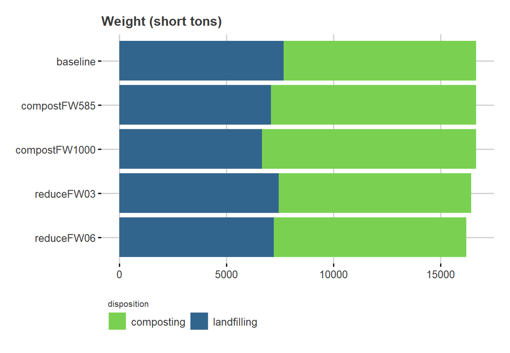

```r
tempWeightChart1 <-
  ggplot()+
  ggtitle("Weight (short tons)")+
  theme_539()+
  geom_bar(
    data = tempWeightData1,
    aes(x = scenario, y= tons, fill= disposition),
    color=NA,
    stat="identity"
  )+
  scale_fill_viridis(begin=0.32, end=0.8, discrete = TRUE,
                     direction = -1)+
  coord_flip()+
  guides(fill=guide_legend(ncol=2, title.position = "top"))+
  theme(
    rect=element_rect(fill="transparent"),
    plot.title = element_text(size=12),
    legend.position="bottom",
    legend.title = element_text(size=8),
    legend.justification="left"
    )
# printing the chart to the current device
tempWeightChart1
```

```r
# saving the chart as external files
ggsave("chart_output/weights.png")
ggsave("chart_output/weights.svg")
```

That chart shows you that most of the scenarios are similar in terms of total weight, and management changes between scenarios are modest.

With a bit more coding, you can produce the same chartwith individual materials separated.

```r
# summing weights by disposition for each scenario
tempWeightData2 <-
  impactsInDetail %>%
  filter(
    LCstage == "endOfLife" &
      impactCategory==sample(impactCategoriesToUse, 1)
    ) %>% # correct set for weight calculations
  group_by(scenario, material, disposition) %>%
  summarise(tons=sum(tons)) %>%
  ungroup() %>%
  filter(tons != 0) %>%
  mutate(scenario= factor(scenario, levels=scenarioOrder))
kable(tempWeightData2)
```

| scenario | material | disposition | tons |
| --- | --- | --- | --- |
| baseline | FoodWaste | landfilling | 7669 |
| baseline | YardDebris | composting | 9000 |
| compostFW1000 | FoodWaste | composting | 1000 |
| compostFW1000 | FoodWaste | landfilling | 6669 |
| compostFW1000 | YardDebris | composting | 9000 |
| compostFW585 | FoodWaste | composting | 585 |
| compostFW585 | FoodWaste | landfilling | 7084 |
| compostFW585 | YardDebris | composting | 9000 |
| reduceFW03 | FoodWaste | landfilling | 7439 |
| reduceFW03 | YardDebris | composting | 9000 |
| reduceFW06 | FoodWaste | landfilling | 7209 |
| reduceFW06 | YardDebris | composting | 9000 |

Making a weight chart with materials separated:

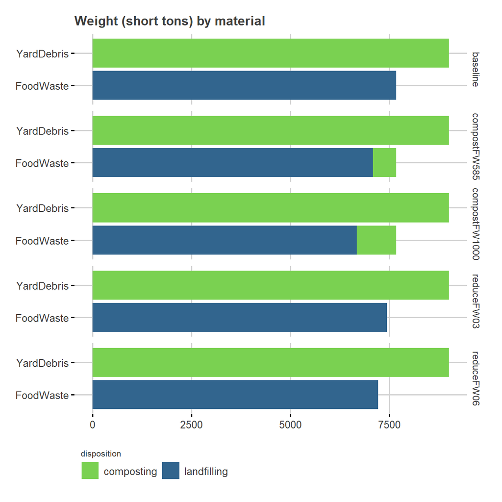

```r
tempWeightChart2 <-
  ggplot()+
  ggtitle("Weight (short tons) by material")+
  theme_539()+
  geom_bar(
    data = tempWeightData2,
    aes(x = material, y= tons, fill= disposition),
    color=NA,
    stat="identity"
  )+
  scale_fill_viridis(begin=0.32, end=0.8, discrete = TRUE,
                     direction = -1)+
  coord_flip()+
  facet_grid(scenario~.)+
  guides(fill=guide_legend(ncol=2, title.position = "top"))+
  theme(
    rect=element_rect(fill="transparent"),
    plot.title = element_text(size=12),
    legend.position="bottom",
    legend.title = element_text(size=8),
    legend.justification="left",
    strip.text=element_text(size=9)
    )
# printing the chart to the current device
tempWeightChart2
```

```r
# saving the chart as external files
ggsave("chart_output/weightsInd.png")
ggsave("chart_output/weightsInd.svg")
```

This chart shows you your massProfiles have described your scenarios fairly. Yard debris does not change its weight throughout all scenarios, while the treatment of food waste varies somewhat.

##### Life cycle impacts for waste in each scenario

Now for comparison, you look at the impacts associated with those scenarios. But here, output will be voluminous, since you have a large number of impact categories to consider: GWP 20, GWP 20 (EpaFcs), Acidification, Ecotoxicity, Eutrophication, Human toxicity, cancer, Ozone depletion, Smog air, Energy demand, Water consumption.

First, sum up the impacts in similar detail to the first weight chart:

```r
tempImpactData1 <-
  impactsInDetail %>%
  group_by(scenario, impactCategory, impactUnits) %>%
  summarise(impact=sum(impact)) %>%
  ungroup() %>%
  mutate(
    scenario = factor(scenario, levels = rev(scenarioOrder)),
    impactLabel =
      paste(
        impactCategory,
        " (",
        impactUnits,
        ")",
        sep=""
      )
  )
kable(tempImpactData1)
```

| scenario | impactCategory | impactUnits | impact | impactLabel |
| --- | --- | --- | --- | --- |
| baseline | Acidification | kg SO2 eq. | 1.536944e+05 | Acidification (kg SO2 eq.) |
| baseline | Ecotoxicity | CTUe | 1.171997e+08 | Ecotoxicity (CTUe) |
| baseline | Energy demand | MJ | 3.040130e+08 | Energy demand (MJ) |
| baseline | Eutrophication | kg N eq. | 1.387923e+05 | Eutrophication (kg N eq.) |
| baseline | GWP 20 | kg CO2 eq. | 3.095864e+07 | GWP 20 (kg CO2 eq.) |
| baseline | GWP 20 (EpaFcs) | kg CO2 eq. | 2.528690e+07 | GWP 20 (EpaFcs) (kg CO2 eq.) |
| baseline | Human toxicity, cancer | CTUh | 4.635636e-01 | Human toxicity, cancer (CTUh) |
| baseline | Ozone depletion | kg CFC 11 eq. | 7.256287e-01 | Ozone depletion (kg CFC 11 eq.) |
| baseline | Smog air | kg O3 eq. | 7.646943e+05 | Smog air (kg O3 eq.) |
| baseline | Water consumption | kg | 1.004051e+09 | Water consumption (kg) |
| compostFW1000 | Acidification | kg SO2 eq. | 1.518486e+05 | Acidification (kg SO2 eq.) |
| compostFW1000 | Ecotoxicity | CTUe | 1.193495e+08 | Ecotoxicity (CTUe) |
| compostFW1000 | Energy demand | MJ | 3.050143e+08 | Energy demand (MJ) |
| compostFW1000 | Eutrophication | kg N eq. | 1.373021e+05 | Eutrophication (kg N eq.) |
| compostFW1000 | GWP 20 | kg CO2 eq. | 3.007787e+07 | GWP 20 (kg CO2 eq.) |
| compostFW1000 | GWP 20 (EpaFcs) | kg CO2 eq. | 2.475148e+07 | GWP 20 (EpaFcs) (kg CO2 eq.) |
| compostFW1000 | Human toxicity, cancer | CTUh | 4.640726e-01 | Human toxicity, cancer (CTUh) |
| compostFW1000 | Ozone depletion | kg CFC 11 eq. | 7.256287e-01 | Ozone depletion (kg CFC 11 eq.) |
| compostFW1000 | Smog air | kg O3 eq. | 7.664987e+05 | Smog air (kg O3 eq.) |
| compostFW1000 | Water consumption | kg | 1.004794e+09 | Water consumption (kg) |
| compostFW585 | Acidification | kg SO2 eq. | 1.523978e+05 | Acidification (kg SO2 eq.) |
| compostFW585 | Ecotoxicity | CTUe | 1.184438e+08 | Ecotoxicity (CTUe) |
| compostFW585 | Energy demand | MJ | 3.031141e+08 | Energy demand (MJ) |
| compostFW585 | Eutrophication | kg N eq. | 1.378910e+05 | Eutrophication (kg N eq.) |
| compostFW585 | GWP 20 | kg CO2 eq. | 3.033852e+07 | GWP 20 (kg CO2 eq.) |
| compostFW585 | GWP 20 (EpaFcs) | kg CO2 eq. | 2.486922e+07 | GWP 20 (EpaFcs) (kg CO2 eq.) |
| compostFW585 | Human toxicity, cancer | CTUh | 4.637999e-01 | Human toxicity, cancer (CTUh) |
| compostFW585 | Ozone depletion | kg CFC 11 eq. | 7.256287e-01 | Ozone depletion (kg CFC 11 eq.) |
| compostFW585 | Smog air | kg O3 eq. | 7.609366e+05 | Smog air (kg O3 eq.) |
| compostFW585 | Water consumption | kg | 1.004219e+09 | Water consumption (kg) |
| reduceFW03 | Acidification | kg SO2 eq. | 1.493455e+05 | Acidification (kg SO2 eq.) |
| reduceFW03 | Ecotoxicity | CTUe | 1.142750e+08 | Ecotoxicity (CTUe) |
| reduceFW03 | Energy demand | MJ | 2.948222e+08 | Energy demand (MJ) |
| reduceFW03 | Eutrophication | kg N eq. | 1.346540e+05 | Eutrophication (kg N eq.) |
| reduceFW03 | GWP 20 | kg CO2 eq. | 3.002770e+07 | GWP 20 (kg CO2 eq.) |
| reduceFW03 | GWP 20 (EpaFcs) | kg CO2 eq. | 2.465349e+07 | GWP 20 (EpaFcs) (kg CO2 eq.) |
| reduceFW03 | Human toxicity, cancer | CTUh | 4.499261e-01 | Human toxicity, cancer (CTUh) |
| reduceFW03 | Ozone depletion | kg CFC 11 eq. | 7.051661e-01 | Ozone depletion (kg CFC 11 eq.) |
| reduceFW03 | Smog air | kg O3 eq. | 7.425039e+05 | Smog air (kg O3 eq.) |
| reduceFW03 | Water consumption | kg | 9.736875e+08 | Water consumption (kg) |
| reduceFW06 | Acidification | kg SO2 eq. | 1.449966e+05 | Acidification (kg SO2 eq.) |
| reduceFW06 | Ecotoxicity | CTUe | 1.113503e+08 | Ecotoxicity (CTUe) |
| reduceFW06 | Energy demand | MJ | 2.856313e+08 | Energy demand (MJ) |
| reduceFW06 | Eutrophication | kg N eq. | 1.305157e+05 | Eutrophication (kg N eq.) |
| reduceFW06 | GWP 20 | kg CO2 eq. | 2.909676e+07 | GWP 20 (kg CO2 eq.) |
| reduceFW06 | GWP 20 (EpaFcs) | kg CO2 eq. | 2.402009e+07 | GWP 20 (EpaFcs) (kg CO2 eq.) |
| reduceFW06 | Human toxicity, cancer | CTUh | 4.362887e-01 | Human toxicity, cancer (CTUh) |
| reduceFW06 | Ozone depletion | kg CFC 11 eq. | 6.847034e-01 | Ozone depletion (kg CFC 11 eq.) |
| reduceFW06 | Smog air | kg O3 eq. | 7.203135e+05 | Smog air (kg O3 eq.) |
| reduceFW06 | Water consumption | kg | 9.433244e+08 | Water consumption (kg) |

For a single impactCategory, we can make an impact chart analagous to the weight chart:

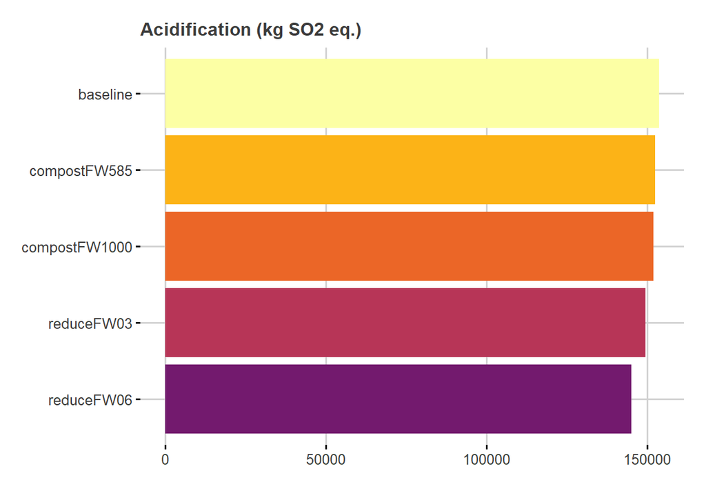

```r
# chose a single impactCategory at random
tempImpactCategory <- sample_n(impactLabels, 1)
# get the impacts for that category
tempImpactChart1 <-
  ggplot()+
  ggtitle(tempImpactCategory$impactLabel)+
  theme_539()+
  geom_bar(
    data =
      tempImpactData1 %>%
        filter(impactCategory==tempImpactCategory$impactCategory),
    aes(x = scenario, y= impact, fill=scenario),
    color=NA,
    stat="identity"
  )+
  scale_fill_viridis(begin=0.32, end=1, discrete = TRUE, option="B")+
  coord_flip()+
  guides(fill=guide_legend(ncol=2, title.position = "top"))+
  theme(
    rect=element_rect(fill="transparent"),
    plot.title = element_text(size=12),
    legend.position="none",
    legend.title = element_text(size=8),
    legend.justification="left"
    )
tempImpactChart1
```

```r
ggsave("chart_output/impacts1.png")
ggsave("chart_output/impacts1.svg")
```

If we use a more complex layout, we can create a single image with facets expressing all of the available impact categories:

[figure not shown]

```r
tempImpactChart1 <-
  ggplot()+
  ggtitle("Impacts of scenarios compared")+
  theme_539()+
  geom_bar(
    data = tempImpactData1,
    aes(x = scenario, y= impact, fill=scenario),
    color=NA,
    # size=2,
    stat="identity"
  )+
  geom_text(
    data=tempImpactData1,
    aes(x=scenario, y=0, label=scenario),
    color="gray80",
    size=3,
    fontface="italic",
    hjust=-0.1
  )+
  facet_wrap(~impactLabel, ncol=2, scales="free")+
  scale_fill_viridis(
    begin=0.1, end=0.7, discrete = TRUE, option="C"
  )+
  coord_flip()+
#  guides(fill=guide_legend(ncol=2, title.position = "top"))+
  theme(
    rect=element_rect(fill="transparent"),
    plot.title = element_text(size=12),
    legend.position="none",
    axis.text.x=element_text(angle=45, hjust=1),
    axis.text.y=element_blank(),
    strip.text = element_text(size=11, face="bold")
    )
tempImpactChart1
```

```r
ggsave("chart_output/impacts2.png")
ggsave("chart_output/impacts2.svg")
```

Such side-by-side results show that management scenarios do not affect all impact categories equally. In the chart above:

- composting realistic amounts of food waste (in scenarios compostFW100 and compostFW585) did reduce GWP slightly, but very slightly.
- the composting scenarios actually increased water consumption very slightly.
- reducing food waste looked to have more of an effect, but again, it was not dramatic.

To find out how this happened, let’s return to the original questions that Anytown’s staff had.

##### Question: which materials and life cycle stages represent the biggest part of this system’s associated life cycle impacts?

To answer this, we’ll make a chart comparing weights and impacts of individual materials, just for a single scenario… “compostFW1000”, which represents a relatively large addition of food waste to yard debris composting.

Unfortunately this takes a bit more coding than the previous charts.

```r
tempWeightData4 <-
  impactsInDetail %>%
  filter(
    LCstage == "endOfLife" & impactCategory=="GWP 100"
  ) %>% # correct set for weight calculations
  group_by(wasteshed, scenario, material, umbDisp) %>%
  summarise(tons=sum(tons)) %>%
  ungroup() %>%
  filter(tons != 0) %>%
  mutate(scenario= factor(scenario, levels=rev(scenarioOrder))) %>%
  mutate(recovTons=ifelse(umbDisp=="recovery",tons,0)) %>%
  mutate(material=factor(material, levels=materialSortOrder))
# creating a data file that expresses weight-based
# recovery rate for each scenario
tempWeightData4a <-
  tempWeightData4 %>%
  group_by(wasteshed, scenario, material) %>%
  summarise(
    recovTons=sum(recovTons),
    tons=sum(tons)
  ) %>%
  ungroup() %>%
  mutate(recovRate=recovTons/tons)
# total weight for the scenario
tempWeightData4b <-
  tempWeightData4a %>%
  group_by(wasteshed, scenario) %>%
  summarise(allTons=sum(tons)) %>%
  ungroup()
# combining that total
tempWeightData4c <-
  full_join(
    tempWeightData4a,
    tempWeightData4b,
    by=c("wasteshed", "scenario")
  ) %>%
  mutate(pctTons=tons/allTons)

# adding impact categories
tempWeightData4d <-
  left_join(
    tempWeightData4c %>% mutate(dummy=1),
    impactLabels %>% mutate(dummy=1),
    by="dummy"
  ) %>%
  select(-dummy)
```

Now processing the impact data into parallel form…

```r
tempImpactData4 <-
  impactsInDetail %>%
  group_by(
    wasteshed,
    scenario,
    material,
    LCstage,
    impactCategory, impactUnits
  ) %>%
  summarise(impact=sum(impact)) %>%
  ungroup() %>%
  mutate(
    scenario = factor(scenario, levels = rev(scenarioOrder)),
    impactLabel =
      paste(
        impactCategory,
        " (",
        impactUnits,
        ")",
        sep=""
      ),
    LCstage=
      factor(
        LCstage,
        levels=c("production","endOfLife","endOfLifeTransport")
      )
  )
tempImpactData4a <-
  tempImpactData4 %>%
  group_by(
    wasteshed,
    scenario,
    material,
    impactCategory,
    impactUnits,
    impactLabel
  ) %>%
  summarise(impact=sum(impact)) %>%
  ungroup()
tempImpactData4b <-
  tempImpactData4a %>%
  group_by(
    wasteshed, scenario, impactCategory, impactUnits, impactLabel
  ) %>%
  summarise(allImpact=sum(impact)) %>%
  ungroup()
tempImpactData4c <-
  full_join(
    tempImpactData4a,
    tempImpactData4b,
    by=c(
      "wasteshed", "scenario", "impactCategory",
      "impactUnits", "impactLabel"
    )
  ) %>%
  mutate(pctImpact=impact/allImpact)
```

now lining those percentages up into a long, skinny file

```r
weightImpactComparisonData1 <-
  bind_rows(
    tempWeightData4d %>%
      select(scenario, wasteshed, material, pctTons, impactLabel) %>%
      rename(pctTotal=pctTons) %>%
      mutate(dataType="weight"),
    tempImpactData4c %>%
      select(scenario, wasteshed, material, pctImpact, impactLabel) %>%
      rename(pctTotal=pctImpact) %>%
      mutate(dataType="impact")
  ) %>%
  arrange(wasteshed, scenario, material, impactLabel)
```

For the chart I’ll separate impact categories.

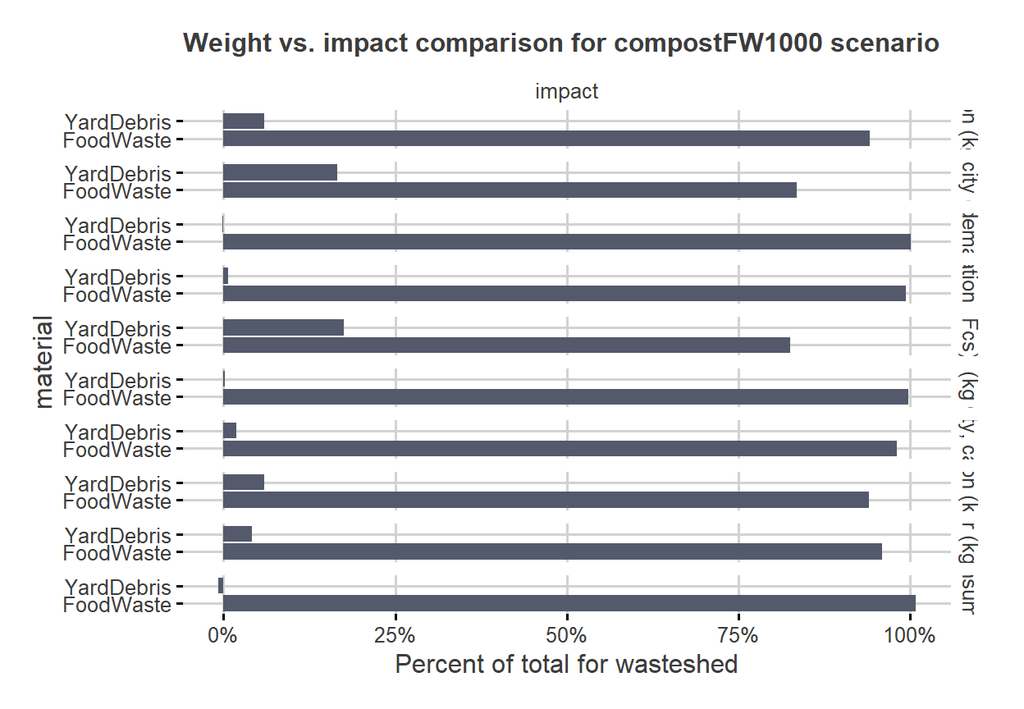

```r
weightImpactComparisonData2 <-
  filter(
    weightImpactComparisonData1,
    scenario=="compostFW1000"
  ) %>%
  mutate(dataType=factor(dataType, levels=c("weight", "impact")))
ggplot()+
  ggtitle("Weight vs. impact comparison for compostFW1000 scenario")+
  theme_539()+
  geom_bar(
    data=weightImpactComparisonData2,
    aes(x=material, y=pctTotal, fill=dataType),
    stat="identity",
    color=NA
  )+
  scale_y_continuous(
    name="Percent of total for wasteshed",
    labels=percent
  )+
  scale_fill_viridis(begin = 0.32, end=0.8,
                      discrete=TRUE,
                      option="cividis",
                      direction=1)+
  facet_grid(impactLabel~dataType)+
  coord_flip()+
  theme(
    rect=element_rect(fill="transparent"),
    axis.ticks=element_line(),
    legend.position="none",
    axis.title=element_text(),
    plot.title=element_text(size=12)
  )
```

```r
ggsave("chart_output/weight_impact_comparison.png")
ggsave("chart_output/weight_impact_comparison.svg")
```

What this shows is that one material is dominating life cycle impacts: food waste. Despite the fact that yard debris is the majority of weight in the system, it contributes very little to the total impact.

##### Question: Are impact reductions from composting food waste substantial?

##### Question: How much do transport distances affect total results?

##### Question: How do the benefits of food waste generation reduction compare to composting?

We can answer these questions from Anytown’s staff by plotting the contributions of individual life cycle stages to total impacts for each material.

```r
# calculating detailed impacts by scenario, material, and LCstage
tempImpactData5 <-
  impactsInDetail %>%
  group_by(
    scenario, material, LCstage, impactCategory, impactUnits
  ) %>%
  summarise(impact=sum(impact)) %>%
  ungroup() %>%
  mutate(
    scenario = factor(scenario, levels = rev(scenarioOrder)),
    impactLabel =
      paste(
        impactCategory,
        " (",
        impactUnits,
        ")",
        sep=""
      ),
    LCstage=
      factor(
        LCstage,
        levels=rev(c("production","endOfLife","endOfLifeTransport"))
      )
  )
# calculating the net totals by scenario and material
tempImpactData5b <-
  tempImpactData5 %>%
  group_by(scenario, material, impactCategory, impactUnits,
           impactLabel) %>%
  summarize(impact=sum(impact))
```

Now making the chart…

[figure not shown]

```r
tempImpactChart5 <-
  ggplot()+
  ggtitle("Detailed impacts by LC stage (net in black)")+
  theme_539()+
  geom_bar(
    data=tempImpactData5,
    aes(x=scenario, y=impact, fill=LCstage),
    color=NA,
    stat="identity",
    alpha=0.5
  )+
  geom_bar(
    data=tempImpactData5b,
    aes(x=scenario, y=impact),
    stat="identity",
    fill=NA,
    color="black"
  )+
  scale_y_continuous(labels=comma)+
  coord_flip()+
  facet_wrap(facets = c("impactLabel","material"), scales="free")+
  scale_fill_viridis(begin=0.32, end=1, discrete = TRUE,
                     direction = -1)+
  theme(
    axis.text.x=element_text(angle=50, hjust=1, vjust=1),
    panel.background=element_blank(),
    panel.grid = element_blank()
  )
tempImpactChart5
```

A careful examination of this chart answers most of the questions from Anytown’s staff.

##### Detailing weight by umbrella disposition

The charts above don’t have a lot of detail about waste management. Let’s redo the weight chart so that it characterizes the weight-based recovery rate in each scenario. For that, we sum weights by scenario and umbDisp:

```r
# summing weights by umbDisp for each scenario
tempWeightData2 <-
  impactsInDetail %>%
  filter(
    LCstage == "endOfLife" & impactCategory == "Energy demand"
  ) %>% # correct set for weight calculations
  group_by(scenario, umbDisp) %>%
  summarise(tons=sum(tons)) %>%
  ungroup() %>%
  filter(tons != 0) %>%
  mutate(scenario= factor(scenario, levels=rev(scenarioOrder))) %>%
  group_by(scenario) %>%
  mutate(recovTons=ifelse(umbDisp=="recovery",tons,0)) %>%
  ungroup()
kable(tempWeightData2)
```

| scenario | umbDisp | tons | recovTons |
| --- | --- | --- | --- |
| baseline | disposal | 7669 | 0 |
| baseline | recovery | 9000 | 9000 |
| compostFW1000 | disposal | 6669 | 0 |
| compostFW1000 | recovery | 10000 | 10000 |
| compostFW585 | disposal | 7084 | 0 |
| compostFW585 | recovery | 9585 | 9585 |
| reduceFW03 | disposal | 7439 | 0 |
| reduceFW03 | recovery | 9000 | 9000 |
| reduceFW06 | disposal | 7209 | 0 |
| reduceFW06 | recovery | 9000 | 9000 |

```r
# creating a data file that expresses weight-based
# recovery rate for each scenario
tempWeightData2a <-
  tempWeightData2 %>%
  group_by(scenario) %>%
  summarise(
    recovTons=sum(recovTons),
    tons=sum(tons)
  ) %>%
  ungroup() %>%
  mutate(recovRate=recovTons/tons)
kable(tempWeightData2a)
```

| scenario | recovTons | tons | recovRate |
| --- | --- | --- | --- |
| reduceFW06 | 9000 | 16209 | 0.5552471 |
| reduceFW03 | 9000 | 16439 | 0.5474786 |
| compostFW1000 | 10000 | 16669 | 0.5999160 |
| compostFW585 | 9585 | 16669 | 0.5750195 |
| baseline | 9000 | 16669 | 0.5399244 |

making that weight data into a chart…

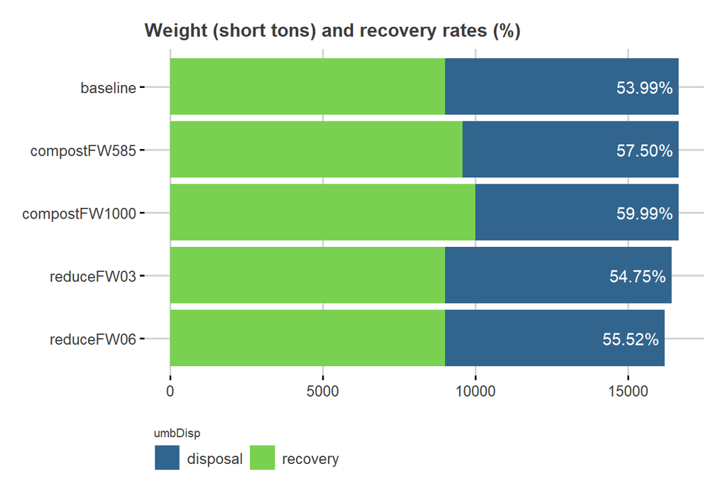

```r
tempWeightChart2 <-
  ggplot()+
  ggtitle("Weight (short tons) and recovery rates (%)")+
  theme_539()+
  geom_bar(
    data = tempWeightData2,
    aes(x = scenario, y= tons, fill= umbDisp),
    color=NA,
    stat="identity"
  )+
  geom_text(
    data=tempWeightData2a,
    aes(x=scenario, y=tons, label=percent(recovRate)),
    hjust=1.1,
    color="white"
  )+
  scale_fill_viridis(
    begin=0.32, end=0.8, option="D", discrete = TRUE
    )+
  coord_flip()+
  guides(fill=guide_legend(ncol=2, title.position = "top"))+
  theme(
    rect=element_rect(fill="transparent"),
    plot.title = element_text(size=12),
    legend.position="bottom",
    legend.title = element_text(size=8),
    legend.justification="left"
    )
tempWeightChart2
```

```r
ggsave("chart_output/weights2.png")
ggsave("chart_output/weights2.svg")
```

##### Illustrating impacts by life cycle stage

Previously the impacts associated with each scenario were given only as net values – the sum of three life cycle stages. It can be interesting to show how those three stages contribute to the net. To do that, we sum impacts by scenario and LCstage:

```r
tempImpactData2 <-
  impactsInDetail %>%
  group_by(scenario, LCstage, impactCategory, impactUnits) %>%
  summarise(impact=sum(impact)) %>%
  ungroup() %>%
  mutate(
    scenario = factor(scenario, levels = rev(scenarioOrder)),
    impactLabel =
      paste(
        impactCategory,
        " (",
        impactUnits,
        ")",
        sep=""
      ),
    LCstage=
      factor(
        LCstage,
        levels=c("production","endOfLife","endOfLifeTransport")
      )
  )
kable(tempImpactData2)
```

| scenario | LCstage | impactCategory | impactUnits | impact | impactLabel |
| --- | --- | --- | --- | --- | --- |
| baseline | endOfLife | Acidification | kg SO2 eq. | 3.124988e+04 | Acidification (kg SO2 eq.) |
| baseline | endOfLife | Ecotoxicity | CTUe | 1.925823e+07 | Ecotoxicity (CTUe) |
| baseline | endOfLife | Energy demand | MJ | -2.436588e+06 | Energy demand (MJ) |
| baseline | endOfLife | Eutrophication | kg N eq. | 1.265725e+04 | Eutrophication (kg N eq.) |
| baseline | endOfLife | GWP 20 | kg CO2 eq. | 7.321697e+06 | GWP 20 (kg CO2 eq.) |
| baseline | endOfLife | GWP 20 (EpaFcs) | kg CO2 eq. | 1.253314e+07 | GWP 20 (EpaFcs) (kg CO2 eq.) |
| baseline | endOfLife | Human toxicity, cancer | CTUh | 7.332600e-03 | Human toxicity, cancer (CTUh) |
| baseline | endOfLife | Ozone depletion | kg CFC 11 eq. | 0.000000e+00 | Ozone depletion (kg CFC 11 eq.) |
| baseline | endOfLife | Smog air | kg O3 eq. | 6.481592e+04 | Smog air (kg O3 eq.) |
| baseline | endOfLife | Water consumption | kg | -4.964241e+05 | Water consumption (kg) |
| baseline | endOfLifeTransport | Acidification | kg SO2 eq. | 6.859959e+02 | Acidification (kg SO2 eq.) |
| baseline | endOfLifeTransport | Ecotoxicity | CTUe | 4.298903e+04 | Ecotoxicity (CTUe) |
| baseline | endOfLifeTransport | Energy demand | MJ | 4.697287e+06 | Energy demand (MJ) |
| baseline | endOfLifeTransport | Eutrophication | kg N eq. | 9.351896e+01 | Eutrophication (kg N eq.) |
| baseline | endOfLifeTransport | GWP 20 | kg CO2 eq. | 3.317936e+05 | GWP 20 (kg CO2 eq.) |
| baseline | endOfLifeTransport | GWP 20 (EpaFcs) | kg CO2 eq. | 3.305057e+05 | GWP 20 (EpaFcs) (kg CO2 eq.) |
| baseline | endOfLifeTransport | Human toxicity, cancer | CTUh | 1.945000e-04 | Human toxicity, cancer (CTUh) |
| baseline | endOfLifeTransport | Ozone depletion | kg CFC 11 eq. | 0.000000e+00 | Ozone depletion (kg CFC 11 eq.) |
| baseline | endOfLifeTransport | Smog air | kg O3 eq. | 1.522895e+04 | Smog air (kg O3 eq.) |
| baseline | endOfLifeTransport | Water consumption | kg | 8.431282e+05 | Water consumption (kg) |
| baseline | production | Acidification | kg SO2 eq. | 1.217585e+05 | Acidification (kg SO2 eq.) |
| baseline | production | Ecotoxicity | CTUe | 9.789846e+07 | Ecotoxicity (CTUe) |
| baseline | production | Energy demand | MJ | 3.017523e+08 | Energy demand (MJ) |
| baseline | production | Eutrophication | kg N eq. | 1.260416e+05 | Eutrophication (kg N eq.) |
| baseline | production | GWP 20 | kg CO2 eq. | 2.330515e+07 | GWP 20 (kg CO2 eq.) |
| baseline | production | GWP 20 (EpaFcs) | kg CO2 eq. | 1.242325e+07 | GWP 20 (EpaFcs) (kg CO2 eq.) |
| baseline | production | Human toxicity, cancer | CTUh | 4.560364e-01 | Human toxicity, cancer (CTUh) |
| baseline | production | Ozone depletion | kg CFC 11 eq. | 7.256287e-01 | Ozone depletion (kg CFC 11 eq.) |
| baseline | production | Smog air | kg O3 eq. | 6.846494e+05 | Smog air (kg O3 eq.) |
| baseline | production | Water consumption | kg | 1.003704e+09 | Water consumption (kg) |

[output cut: 120 more lines]

Now make that into a chart, with life cycle stage impacts in colors, and the (previously calculated) net impact as a black outline.

[figure not shown]

```r
tempImpactChart2 <-
  ggplot()+
  ggtitle("Impacts of scenarios with life cycle stage detail")+
  theme_539()+
  geom_bar(
    data = tempImpactData2,
    aes(x = scenario, y= impact, fill=LCstage),
    color=NA,
    # size=2,
    stat="identity"
  )+
  geom_bar(
    data=tempImpactData1 %>% mutate(LCstage="Net"),
    aes(x=scenario, y=impact, color=LCstage),
    stat="identity",
    fill=NA,
    size=2
  )+
  geom_text(
    data=tempImpactData1 %>% mutate(LCstage="Net"),
    aes(x=scenario, y=0, label=scenario),
    stat="identity",
    color="gray20",
    size=3,
    fontface="italic",
    hjust=-0.1,
    vjust=0.5
  )+
  facet_wrap(~impactLabel, ncol=2, scales="free")+
  scale_color_manual(values="black")+
  scale_fill_viridis(
    begin=0.32, end=0.95, option="E", discrete = TRUE,
    direction = -1
  )+
  coord_flip()+
  guides(
    color=guide_legend(nrow=1, title=NULL),
    fill=guide_legend(nrow=1, title.position = "left")
    )+
  theme(
    rect=element_rect(fill="transparent"),
    plot.title = element_text(size=12),
    legend.position="top",
    axis.text.x=element_text(angle=45, hjust=1),
    axis.text.y=element_blank(),
    strip.text = element_text(size=11, face="bold")
    )
tempImpactChart2
```

```r
ggsave("chart_output/impacts3.png")
ggsave("chart_output/impacts3.svg")
```

##### Heatmap

Another way to compare impact results across scenarios is the “heatmap”, where all impacts are scaled to the baseline value.

Here is the code to produce a data table which can be drawn as a heatmap:

```r
tempImpactData3 <-
  tempImpactData1 %>%
  filter(scenario=="baseline") %>%
  select(impactLabel, impact) %>%
  rename(baselineImpact=impact)
tempImpactData3a <-
  left_join(
    tempImpactData1,
    tempImpactData3,
    by= c("impactLabel")
  ) %>%
  mutate(
    pctBaselineImpact=impact/baselineImpact
  )
kable(tempImpactData3a)
```

| scenario | impactCategory | impactUnits | impact | impactLabel | baselineImpact | pctBaselineImpact |
| --- | --- | --- | --- | --- | --- | --- |
| baseline | Acidification | kg SO2 eq. | 1.536944e+05 | Acidification (kg SO2 eq.) | 1.536944e+05 | 1.0000000 |
| baseline | Ecotoxicity | CTUe | 1.171997e+08 | Ecotoxicity (CTUe) | 1.171997e+08 | 1.0000000 |
| baseline | Energy demand | MJ | 3.040130e+08 | Energy demand (MJ) | 3.040130e+08 | 1.0000000 |
| baseline | Eutrophication | kg N eq. | 1.387923e+05 | Eutrophication (kg N eq.) | 1.387923e+05 | 1.0000000 |
| baseline | GWP 20 | kg CO2 eq. | 3.095864e+07 | GWP 20 (kg CO2 eq.) | 3.095864e+07 | 1.0000000 |
| baseline | GWP 20 (EpaFcs) | kg CO2 eq. | 2.528690e+07 | GWP 20 (EpaFcs) (kg CO2 eq.) | 2.528690e+07 | 1.0000000 |
| baseline | Human toxicity, cancer | CTUh | 4.635636e-01 | Human toxicity, cancer (CTUh) | 4.635636e-01 | 1.0000000 |
| baseline | Ozone depletion | kg CFC 11 eq. | 7.256287e-01 | Ozone depletion (kg CFC 11 eq.) | 7.256287e-01 | 1.0000000 |
| baseline | Smog air | kg O3 eq. | 7.646943e+05 | Smog air (kg O3 eq.) | 7.646943e+05 | 1.0000000 |
| baseline | Water consumption | kg | 1.004051e+09 | Water consumption (kg) | 1.004051e+09 | 1.0000000 |
| compostFW1000 | Acidification | kg SO2 eq. | 1.518486e+05 | Acidification (kg SO2 eq.) | 1.536944e+05 | 0.9879905 |
| compostFW1000 | Ecotoxicity | CTUe | 1.193495e+08 | Ecotoxicity (CTUe) | 1.171997e+08 | 1.0183437 |
| compostFW1000 | Energy demand | MJ | 3.050143e+08 | Energy demand (MJ) | 3.040130e+08 | 1.0032936 |
| compostFW1000 | Eutrophication | kg N eq. | 1.373021e+05 | Eutrophication (kg N eq.) | 1.387923e+05 | 0.9892625 |
| compostFW1000 | GWP 20 | kg CO2 eq. | 3.007787e+07 | GWP 20 (kg CO2 eq.) | 3.095864e+07 | 0.9715501 |
| compostFW1000 | GWP 20 (EpaFcs) | kg CO2 eq. | 2.475148e+07 | GWP 20 (EpaFcs) (kg CO2 eq.) | 2.528690e+07 | 0.9788265 |
| compostFW1000 | Human toxicity, cancer | CTUh | 4.640726e-01 | Human toxicity, cancer (CTUh) | 4.635636e-01 | 1.0010979 |
| compostFW1000 | Ozone depletion | kg CFC 11 eq. | 7.256287e-01 | Ozone depletion (kg CFC 11 eq.) | 7.256287e-01 | 1.0000000 |
| compostFW1000 | Smog air | kg O3 eq. | 7.664987e+05 | Smog air (kg O3 eq.) | 7.646943e+05 | 1.0023596 |
| compostFW1000 | Water consumption | kg | 1.004794e+09 | Water consumption (kg) | 1.004051e+09 | 1.0007408 |
| compostFW585 | Acidification | kg SO2 eq. | 1.523978e+05 | Acidification (kg SO2 eq.) | 1.536944e+05 | 0.9915637 |
| compostFW585 | Ecotoxicity | CTUe | 1.184438e+08 | Ecotoxicity (CTUe) | 1.171997e+08 | 1.0106151 |
| compostFW585 | Energy demand | MJ | 3.031141e+08 | Energy demand (MJ) | 3.040130e+08 | 0.9970433 |
| compostFW585 | Eutrophication | kg N eq. | 1.378910e+05 | Eutrophication (kg N eq.) | 1.387923e+05 | 0.9935056 |
| compostFW585 | GWP 20 | kg CO2 eq. | 3.033852e+07 | GWP 20 (kg CO2 eq.) | 3.095864e+07 | 0.9799695 |
| compostFW585 | GWP 20 (EpaFcs) | kg CO2 eq. | 2.486922e+07 | GWP 20 (EpaFcs) (kg CO2 eq.) | 2.528690e+07 | 0.9834825 |
| compostFW585 | Human toxicity, cancer | CTUh | 4.637999e-01 | Human toxicity, cancer (CTUh) | 4.635636e-01 | 1.0005097 |
| compostFW585 | Ozone depletion | kg CFC 11 eq. | 7.256287e-01 | Ozone depletion (kg CFC 11 eq.) | 7.256287e-01 | 1.0000000 |
| compostFW585 | Smog air | kg O3 eq. | 7.609366e+05 | Smog air (kg O3 eq.) | 7.646943e+05 | 0.9950860 |
| compostFW585 | Water consumption | kg | 1.004219e+09 | Water consumption (kg) | 1.004051e+09 | 1.0001680 |
| reduceFW03 | Acidification | kg SO2 eq. | 1.493455e+05 | Acidification (kg SO2 eq.) | 1.536944e+05 | 0.9717043 |
| reduceFW03 | Ecotoxicity | CTUe | 1.142750e+08 | Ecotoxicity (CTUe) | 1.171997e+08 | 0.9750455 |
| reduceFW03 | Energy demand | MJ | 2.948222e+08 | Energy demand (MJ) | 3.040130e+08 | 0.9697682 |
| reduceFW03 | Eutrophication | kg N eq. | 1.346540e+05 | Eutrophication (kg N eq.) | 1.387923e+05 | 0.9701834 |
| reduceFW03 | GWP 20 | kg CO2 eq. | 3.002770e+07 | GWP 20 (kg CO2 eq.) | 3.095864e+07 | 0.9699295 |
| reduceFW03 | GWP 20 (EpaFcs) | kg CO2 eq. | 2.465349e+07 | GWP 20 (EpaFcs) (kg CO2 eq.) | 2.528690e+07 | 0.9749513 |
| reduceFW03 | Human toxicity, cancer | CTUh | 4.499261e-01 | Human toxicity, cancer (CTUh) | 4.635636e-01 | 0.9705812 |
| reduceFW03 | Ozone depletion | kg CFC 11 eq. | 7.051661e-01 | Ozone depletion (kg CFC 11 eq.) | 7.256287e-01 | 0.9718001 |
| reduceFW03 | Smog air | kg O3 eq. | 7.425039e+05 | Smog air (kg O3 eq.) | 7.646943e+05 | 0.9709813 |
| reduceFW03 | Water consumption | kg | 9.736875e+08 | Water consumption (kg) | 1.004051e+09 | 0.9697594 |
| reduceFW06 | Acidification | kg SO2 eq. | 1.449966e+05 | Acidification (kg SO2 eq.) | 1.536944e+05 | 0.9434085 |
| reduceFW06 | Ecotoxicity | CTUe | 1.113503e+08 | Ecotoxicity (CTUe) | 1.171997e+08 | 0.9500909 |
| reduceFW06 | Energy demand | MJ | 2.856313e+08 | Energy demand (MJ) | 3.040130e+08 | 0.9395364 |
| reduceFW06 | Eutrophication | kg N eq. | 1.305157e+05 | Eutrophication (kg N eq.) | 1.387923e+05 | 0.9403668 |
| reduceFW06 | GWP 20 | kg CO2 eq. | 2.909676e+07 | GWP 20 (kg CO2 eq.) | 3.095864e+07 | 0.9398590 |
| reduceFW06 | GWP 20 (EpaFcs) | kg CO2 eq. | 2.402009e+07 | GWP 20 (EpaFcs) (kg CO2 eq.) | 2.528690e+07 | 0.9499026 |
| reduceFW06 | Human toxicity, cancer | CTUh | 4.362887e-01 | Human toxicity, cancer (CTUh) | 4.635636e-01 | 0.9411625 |
| reduceFW06 | Ozone depletion | kg CFC 11 eq. | 6.847034e-01 | Ozone depletion (kg CFC 11 eq.) | 7.256287e-01 | 0.9436003 |
| reduceFW06 | Smog air | kg O3 eq. | 7.203135e+05 | Smog air (kg O3 eq.) | 7.646943e+05 | 0.9419627 |
| reduceFW06 | Water consumption | kg | 9.433244e+08 | Water consumption (kg) | 1.004051e+09 | 0.9395188 |

now, to make that into a chart:

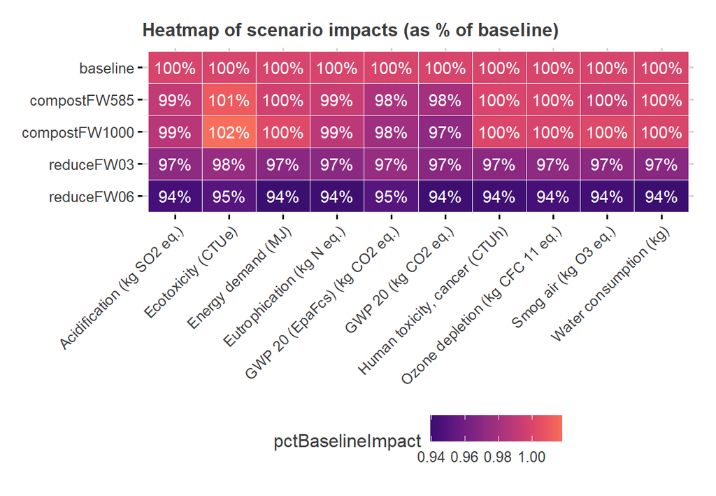

```r
tempImpactChart3 <-
  ggplot()+
  ggtitle("Heatmap of scenario impacts (as % of baseline)")+
  theme_539()+
  geom_tile(
    data=tempImpactData3a,
    aes(y=scenario, x=impactLabel, fill=pctBaselineImpact),
    color="white"
  )+
  geom_text(
    data=tempImpactData3a,
    aes(
      y=scenario, x=impactLabel, label=percent(pctBaselineImpact,1)
    ),
    color="white"
  )+
  scale_fill_viridis(begin=0.2, end=0.7, option="A")+
  theme(
    plot.title = element_text(size=12),
    rect=element_rect(fill="transparent"),
    panel.grid = element_blank(),
    axis.ticks = element_line(),
    axis.text.x = element_text(hjust=1, angle=45)
  )
tempImpactChart3
```

```r
ggsave("chart_output/impacts4.png")
ggsave("chart_output/impacts4.svg")
```

##### Weight vs impacts within a single scenario